# Word Prediction

2023-04-17

# Synopsis

The objective of this project is creating a Language Model to predict the next word taking as input the last words written by an user. The model is trained using data coming from Twitter, blogs and news, to have a various type of options. The data is preprocessed to delete foreign words, delete punctuation and curse words, among others. The exploratory analysis showed that the corpus is composed by mainly a small set of words, while existing a great amount of low-frequency words.

The created model makes an interpolation of trigrams, bigrams and unigrams probabilities. Nevertheless, testing the parameters needed for better complexity showed that the best was giving all the weight to the trigrams, ignoring unigrams and bigrams. Not all the data has been used for the training and testing, since the machine used is old and has not much capacity. Some optimization has been applied, like clustering and vectorial filtering.

- [Shiny app](https://eloyinsunza.shinyapps.io/WordPredictor/)
- [Slides presentation](https://rpubs.com/EloyID/1037248)

# Preprocessing

The data sources are Twitter, blogs and news and the raw data can be found in this [link](https://d396qusza40orc.cloudfront.net/dsscapstone/dataset/Coursera-SwiftKey.zip).

The data is split in three groups, training, validation and testing with proportions 60-20-20. The following output shows an extract of the training data set.

```
## <<SimpleCorpus>>
## Metadata:  corpus specific: 1, document level (indexed): 0
## Content:  documents: 3
##
## [1] you guys doing Danny James' "Pear" on lp?!
## [2] God has over 2 Billion followers and He didn't even need Twitter!
## [3] Some things, the Oscars can't change.
```

The preprocessing includes the following steps: - Skip the lines in foreign languages, the model predicts English words. - Filter profanity words using the list provided by google and imported from this url - Remove numbers and punctuation. - Replace contractions like ’ve, ’d, ’s because the predictor will not propose this contractions. - Lowercase - Remove any element not being a character and stripping whitespaces not being single spaces. Nevertheless, common practices like stemming or deleting stop words will not be applied. The model needs to correctly predict stop words (like “to” after “I want”) and full words, not just the stem.

After preprocessing, the extract looks as follows:

```
## <<SimpleCorpus>>
## Metadata:  corpus specific: 1, document level (indexed): 0
## Content:  documents: 3
##
## [1] you guys doing danny james pear on lp
## [2] god has over billion followers and he did not even need twitter
## [3] some things the oscars can not change
```

# Exploratory data analysis

## Unigrams, bigrams and trigrams distribution

The following word cloud shows the most used words in the training data set. As expected, among them stop words and common verbs. The following plot shows that most of the words appear only once.

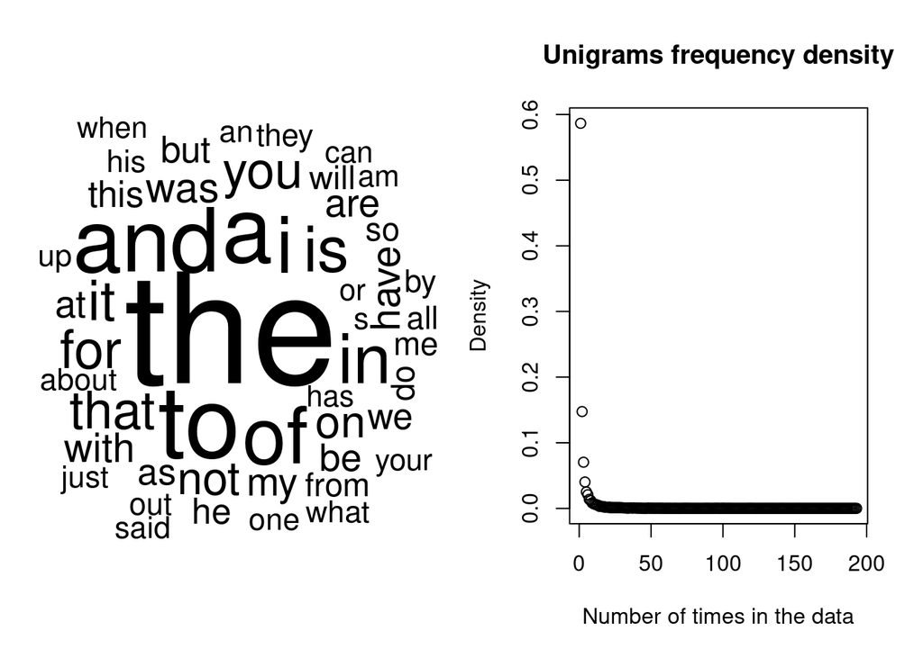

The following word cloud shows the most used bigrams in the training data set. As expected, among them a combination of stop words and common verbs. The density plot is similar to the precedent one, but even more gathered to the initial values. This is logical, every unique word will create unique bigrams.

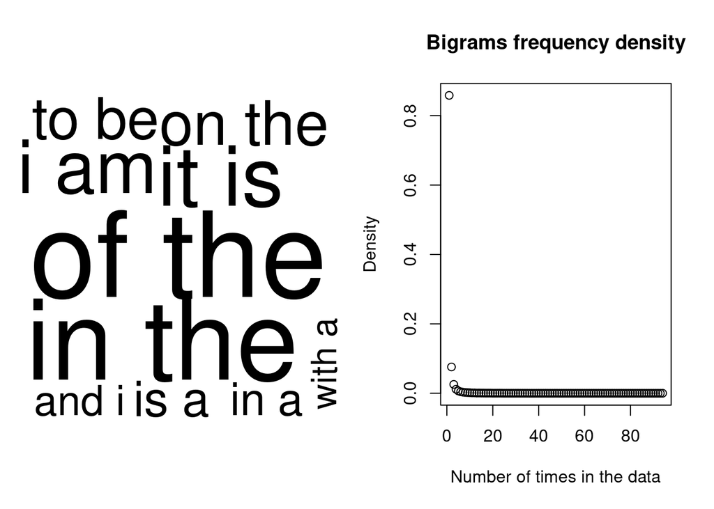

The next plots shows that the trend seen in the bigrams continues for the trigrams.

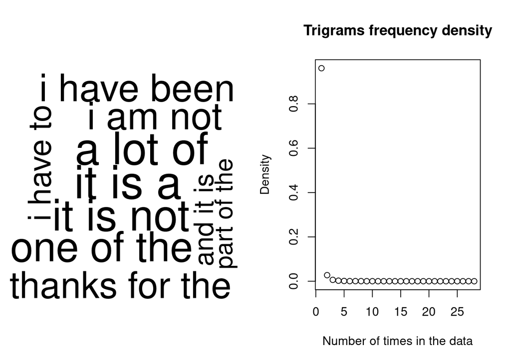

## Vocabulary coverage

```
##   Words.coverage.. Words.coverage Vocabulary.needed Vocabulary.needed..
## 1             0.50          32990               585               0.039
## 2             0.75          49485              2308               0.156
## 3             0.90          59382              6129               0.413
## 4             0.95          62681              6131               0.414
## 5             1.00          65980             14824               1.000
```

# Model

For this first try of the project, a model is tried with the following elements - Words candidates from matching trigrams, bigrams and most common unigram - Probabilities with interpolation of trigrams, bigrams and unigrams. - The parameters for this interpolation will be found calculating the perplexity - To model the unknown tokens, in the training set the low frequency words (appearing 5 times or less) will be treated as unknown tokens. Here is the code which predicts the words

```r
most_common_unigram = unigrams_freq[1, ]$unigrams

# takes a text and using the last two words, tries to predict the next word
# text: the text input
# trigrams_coef: weight given to the trigrams prediction
# bigrams_coef: weight given to the bigrams prediction
# unigrams_coef: weight given to the unigrams prediction
# returns a dataframe with the columns words and probability
predict_next_word = function(text,
                             trigrams_coef = 0.6,
                             bigrams_coef = 0.3,
                             unigrams_coef = 0.1) {
  words = strsplit(text, " ")[[1]]
  words_count = length(words)

  # break the text words
  if (words_count == 0) {
    return("")
  }
  if (words_count >= 1) {
    last_word_1_input = words[words_count]
    if (is_word_unkown(last_word_1_input))
      last_word_1_input = unknown_word_token
  }
  if (words_count >= 2) {
    last_word_2_input = words[words_count - 1]
    if (is_word_unkown(last_word_2_input))
      last_word_2_input = unknown_word_token
  } else {
    last_word_2_input = NA
  }

  # check the trigrams and bigrams for the words
  if (trigrams_coef != 0) {
    trigrams_result = trigrams_freq_with_unk[trigrams_freq_with_unk$last_word_2 == last_word_2_input &
                                               trigrams_freq_with_unk$last_word_1 == last_word_1_input &
                                               trigrams_freq_with_unk$last_word != unknown_word_token
                                             , ]
  } else {
    trigrams_result = data.frame(last_word = c(), logprobability = c())
  }

  if (bigrams_coef != 0) {
    bigrams_result = bigrams_freq_with_unk[bigrams_freq_with_unk$last_word_1 == last_word_1_input &
                                             bigrams_freq_with_unk$last_word != unknown_word_token
                                           , ]
  } else {
    bigrams_result = data.frame(last_word = c(), logprobability = c())
  }

  # if no result return the most common unigram
  if (NROW(trigrams_result) == 0 & NROW(bigrams_result) == 0)
    return(data.frame(
      words = c(most_common_unigram),
      probability = 1
    ))

  # get the probability of the candidates as unigrams
  if (unigrams_coef != 0) {
    candidate_words = c(trigrams_result$last_word, bigrams_result$last_word)
    unigrams_result =  unigrams_high_freq[unigrams_high_freq$unigrams %in% candidate_words, ]
  } else {
    unigrams_result = data.frame(unigrams = c(), logprobability = c())
  }

  log_trigrams_coef = ifelse(trigrams_coef == 0, 0, log(trigrams_coef))
  log_bigrams_coef = ifelse(bigrams_coef == 0, 0, log(bigrams_coef))
  log_unigrams_coef = ifelse(unigrams_coef == 0, 0, log(unigrams_coef))

  # join the scores for each word as tri, bi or unigram
  probabilities_result = data.frame(
    words = c(
      trigrams_result$last_word,
      bigrams_result$last_word,
      as.character(unigrams_result$unigrams)
    ),
    score = c(
      log_trigrams_coef + trigrams_result$logprobability,
      log_bigrams_coef + bigrams_result$logprobability,
      log_unigrams_coef + unigrams_result$logprobability
    )
  )

  probabilities_result = probabilities_result %>%
    # add the scores of the same words as tri, bi or unigram
    group_by(words) %>%
    summarize(score = sum(exp(score))) %>%
    # calculate the probability as standardizing the score
    mutate(probability = score / sum(score)) %>%
    arrange(desc(score))

  probabilities_result
}


predict_next_word_with_preprocess = function(text,
                                             trigrams_coef = 0.6,
                                             bigrams_coef = 0.3,
                                             unigrams_coef = 0.1) {
  text_corpus = SimpleCorpus(VectorSource(text))
  preprocessed_text_corpus = preprocess_raw_corpus(text_corpus)
  preprocessed_text = preprocessed_text_corpus[[1]]$content
  predict_next_word(
    preprocessed_text,
    trigrams_coef = trigrams_coef,
    bigrams_coef = bigrams_coef,
    unigrams_coef = unigrams_coef
  )
}
```

When called with the sentence “sth sth sth sth I want to” the following is obtained (first 10 rows)

```
## # A tibble: 10 × 3
##    words  score probability
##    <chr>  <dbl>       <dbl>
##  1 be    0.0812      0.0983
##  2 see   0.0564      0.0683
##  3 do    0.0467      0.0566
##  4 hear  0.0319      0.0386
##  5 the   0.0287      0.0347
##  6 make  0.0284      0.0343
##  7 go    0.0249      0.0301
##  8 know  0.022       0.0266
##  9 miss  0.021       0.0255
## 10 move  0.021       0.0255
```

## Parameters

```
##   trigrams.parameter bigrams.parameter unigrams.parameter perplexity
## 1                1.0               0.0                0.0       3.60
## 2                0.6               0.4                0.0       4.54
## 3                0.6               0.3                0.1       4.45
## 4                0.3               0.6                0.1       5.92
```

The model applied on the testing data gives the following perplexity value which is similar to the one obtained before.

```
## [1] 3.554208
```

# Conclusion

The created model shows capacity to predict the following word, but it has some major problems to be corrected.

- It cannot predict the use of numbers, punctuation or even uppercase.
- The perplexity is biased since a arbitrary number has been used as probability if the word to predict were not in the list.
- The modelling of unknown words could be done with Touring smoothing
- The test has a correct perplexity because the source of the data is the same as for the testing and training
- The perplexity has been made on a preprocessed data, because with punctuation, numbers and uppercase the perplexity would be much higher.

# Annex : code

```r
set.seed(1234)
library(NLP)
library(tm)
library(tokenizers)
library(ggplot2)
library(dplyr)
library(cld2)
library(qdap)
library(stringi)
library(zeallot)
library(wordcloud)
library(tidyr)
library(parallel)

con <-
  file("Coursera-SwiftKey/final/en_US/en_US.twitter.txt", open = "r")
twitter_raw_data <- readLines(con, encoding = "UTF-8")
close(con)
con <-
  file("Coursera-SwiftKey/final/en_US/en_US.blogs.txt", open = "r")
blogs_raw_data <- readLines(con, encoding = "UTF-8")
close(con)
con <-
  file("Coursera-SwiftKey/final/en_US/en_US.news.txt", open = "r")
news_raw_data <- readLines(con, encoding = "UTF-8")
close(con)

# join all the data
raw_data = c(twitter_raw_data, blogs_raw_data, news_raw_data)

# useful if you want a smaller data set and work quicker
sample_proportion = 0.001 # use if you don't want all the data to be read

if (is.numeric(sample_proportion)) {
  raw_data <- sample(raw_data,
                     size = sample_proportion * length(raw_data),
                     replace = FALSE)
}

# filter foreign sentences
# if the function is not sure about the language (NA), it is included
english_raw_data = raw_data[detect_language(raw_data) %in% c("en", NA)]

# training-validation-testing proportions
training_proportion = 0.6
validation_proportion = 0.2
testing_proportion = 1 - training_proportion - validation_proportion

# splitting the data
testing_split = testing_proportion
rows_in_testing_set <-
  as.logical(rbinom(NROW(english_raw_data), 1, testing_split))
testing_raw_data <- english_raw_data[rows_in_testing_set]
no_testing_raw_data <- english_raw_data[-rows_in_testing_set]

validation_split = validation_proportion /
  (validation_proportion + training_proportion)
rows_in_validation_set <-
  as.logical(rbinom(NROW(no_testing_raw_data), 1, validation_split))
validation_raw_data <- no_testing_raw_data[rows_in_validation_set]
training_raw_data <- no_testing_raw_data[-rows_in_validation_set]

# use if you want smaller sets for the testing and validation
sample_testing_validation_proportion = 0.05
if (is.numeric(sample_testing_validation_proportion)) {
  validation_raw_data <- sample(
    validation_raw_data,
    size = sample_testing_validation_proportion * length(validation_raw_data),
    replace = FALSE
  )
  testing_raw_data <- sample(testing_raw_data,
                             size = sample_testing_validation_proportion * length(testing_raw_data),
                             replace = FALSE)
}

# create the corpus
raw_testing_corpus <- SimpleCorpus(VectorSource(testing_raw_data))
raw_validation_corpus <-
  SimpleCorpus(VectorSource(validation_raw_data))
raw_training_corpus <- SimpleCorpus(VectorSource(training_raw_data))

inspect(raw_training_corpus[1:3])


# profanity words pre-work
profanityWordsFile = "bad-words.txt"
profanityWordsUrl = "https://raw.githubusercontent.com/coffee-and-fun/google-profanity-words/main/data/list.txt"
if (!file.exists(profanityWordsFile)) {
  download.file(profanityWordsUrl, destfile = profanityWordsFile)
}
profanityTokens = tokenize_lines(readLines(profanityWordsFile))


# Takes a rawCropus as SimpleCorpus object as input and applies the following preprocessing steps :
# 1. Remove profanity words
# 2. Remove numbers
# 3. Replace word contractions
# 4. Remove punctuation
# 5. To lowercase
# 6. Remove not character elements
# 7. Remove not standard whitespaces

# raw_corpus: SimpleCorpus object to preprocess
# returns the SimpleCorpus object after having followed the indicated steps
preprocess_raw_corpus = function(raw_corpus) {
  tranformed_raw_corpus <- raw_corpus
  tranformed_raw_corpus <-
    tm_map(tranformed_raw_corpus,
           removeWords,
           unlist(profanityTokens))
  tranformed_raw_corpus <-
    tm_map(tranformed_raw_corpus, removeNumbers)
  tranformed_raw_corpus <-
    tm_map(tranformed_raw_corpus,
           content_transformer(replace_contraction))
  tranformed_raw_corpus <-
    tm_map(tranformed_raw_corpus, removePunctuation)
  tranformed_raw_corpus <-
    tm_map(tranformed_raw_corpus, content_transformer(tolower))

  symbolsToSpace <-
    content_transformer(function(x, pattern)
      gsub(pattern, " ", x))
  tranformed_raw_corpus <-
    tm_map(tranformed_raw_corpus, symbolsToSpace, "[^a-zA-Z]")
  tranformed_raw_corpus <-
    tm_map(tranformed_raw_corpus, stripWhitespace)
  tranformed_raw_corpus
}

preprocessed_testing_corpus = preprocess_raw_corpus(raw_testing_corpus)
preprocessed_validation_corpus = preprocess_raw_corpus(raw_validation_corpus)
preprocessed_training_corpus = preprocess_raw_corpus(raw_training_corpus)

inspect(preprocessed_training_corpus[1:3])

# list of all words
unigrams = tokenize_words(paste(preprocessed_training_corpus$content, collapse = " "))
# data frame with
# Freq: freq of each word
# unigrams: word
unigrams_freq = as.data.frame(table(unigrams))
unigrams_freq = arrange(unigrams_freq, desc(Freq))
# data frame with the Freq of word frequencies
# Freq: freq of word frequency
# Var1: word frequency
# Example: if there are 60 different words appearing 78 times each,
# Var1: 78, Freq: 60
unigrams_freq_freq = as.data.frame(table(table(unigrams)))
unigrams_freq_freq$density = unigrams_freq_freq$Freq /
  sum(unigrams_freq_freq$Freq)

# list of all bigrams
bigrams = unlist(tokenize_ngrams(preprocessed_training_corpus$content, n = 2))
# data frame with
# Freq: freq of each bigram
# bigrams: bigram
bigrams_freq = as.data.frame(table(bigrams))
bigrams_freq = arrange(bigrams_freq, desc(Freq))
bigrams_freq$bigrams = factor(bigrams_freq$bigrams, levels = bigrams_freq$bigrams)
bigrams_freq <- separate(
  bigrams_freq,
  bigrams,
  c("last_word_1", "last_word"),
  sep = " ",
  remove = FALSE
)
# data frame with the Freq of bigram frequencies
# Freq: freq of bigram frequency
# Var1: bigram frequency
# Example: if there are 60 different bigrams appearing 78 times each,
# Var1: 78, Freq: 60
bigrams_freq_freq = as.data.frame(table(table(bigrams)))
bigrams_freq_freq$density = bigrams_freq_freq$Freq / sum(bigrams_freq_freq$Freq)
```

```r
# list of all trigrams
trigrams = unlist(tokenize_ngrams(preprocessed_training_corpus$content, n = 3))
# data frame with
# Freq: freq of each trigram
# trigrams: trigram
trigrams_freq = as.data.frame(table(trigrams))
trigrams_freq = arrange(trigrams_freq, desc(Freq))
trigrams_freq$trigrams = factor(trigrams_freq$trigrams, levels = trigrams_freq$trigrams)
trigrams_freq <-
  separate(
    trigrams_freq,
    trigrams,
    c("last_word_2", "last_word_1", "last_word"),
    sep = " ",
    remove = FALSE
  )
# data frame with the Freq of trigram frequencies
# Freq: freq of trigram frequency
# Var1: trigram frequency
# Example: if there are 60 different trigrams appearing 78 times each,
# Var1: 78, Freq: 60
trigrams_freq_freq = as.data.frame(table(table(trigrams)))
trigrams_freq_freq$density = trigrams_freq_freq$Freq / sum(trigrams_freq_freq$Freq)
layout(matrix(c(1, 2), nrow = 1))

wordcloud(
  unigrams_freq$unigrams,
  unigrams_freq$Freq,
  scale = c(7, 1),
  max.words = 50,
  random.order = FALSE
)

plot(
  unigrams_freq_freq$density,
  main = "Unigrams frequency density",
  xlab = "Number of times in the data",
  ylab = "Density"
)
layout(matrix(c(1, 2), nrow = 1))

wordcloud(
  bigrams_freq$bigrams,
  bigrams_freq$Freq,
  scale = c(7, 1),
  max.words = 50,
  random.order = FALSE
)

plot(
  bigrams_freq_freq$density,
  main = "Bigrams frequency density",
  xlab = "Number of times in the data",
  ylab = "Density"
)
layout(matrix(c(1, 2), nrow = 1))

wordcloud(
  trigrams_freq$trigrams,
  trigrams_freq$Freq,
  scale = c(7, 1),
  max.words = 50,
  random.order = FALSE
)

plot(
  trigrams_freq_freq$density,
  main = "Trigrams frequency density",
  xlab = "Number of times in the data",
  ylab = "Density"
)

# total of different words
vocabulary_size = sum(unigrams_freq_freq$Freq)
# total words
words_instances = sum(unigrams_freq_freq$Freq * as.numeric(unigrams_freq_freq$Var1))

# calculate number of different words to cover word_coverage proportion of total
# words
# word_coverage: proportion of total words to be covered between 0 and 1
# returns number of words needed
calculate_dico_size_for_word_coverage = function(word_coverage) {
  unigrams_freq_freq_desc = arrange(unigrams_freq_freq, desc(Var1))
  unigrams_freq_freq_desc$Var1 = as.numeric(unigrams_freq_freq_desc$Var1)
  word_instances_covered = word_coverage * words_instances
  index = which(
    cumsum(
      unigrams_freq_freq_desc$Var1 * unigrams_freq_freq_desc$Freq
    ) > word_instances_covered
  )[[1]]
  index_1 = index - 1
  needed_words_count = sum(unigrams_freq_freq_desc[1:(index_1), ]$Freq) +
    (
      word_instances_covered -
        sum(
          unigrams_freq_freq_desc[1:(index_1), ]$Var1 *
            unigrams_freq_freq_desc[1:(index_1), ]$Freq
        )
    ) /
    unigrams_freq_freq_desc[index_1, ]$Freq

  ceiling(needed_words_count)
}

words_50_coverage = calculate_dico_size_for_word_coverage(word_coverage = 0.5)
words_75_coverage = calculate_dico_size_for_word_coverage(word_coverage = 0.75)
words_90_coverage = calculate_dico_size_for_word_coverage(word_coverage = 0.9)
words_95_coverage = calculate_dico_size_for_word_coverage(word_coverage = 0.95)

word_coverage_data_frame = data.frame(
  `Words coverage %` = c(0.5, 0.75, 0.9, 0.95, 1),
  `Words coverage` = floor(words_instances * c(0.5, 0.75, 0.9, 0.95, 1)),
  `Vocabulary needed` = c(
    words_50_coverage,
    words_75_coverage,
    words_90_coverage,
    words_95_coverage,
    vocabulary_size
  ),
  `Vocabulary needed %` = round(
    c(
      words_50_coverage,
      words_75_coverage,
      words_90_coverage,
      words_95_coverage,
      vocabulary_size
    ) / vocabulary_size,
    3
  )
)


word_threshold = 5
# two data frames with the unigrams separated by the threshold
unigrams_high_freq = filter(unigrams_freq, Freq > word_threshold)
unigrams_low_freq = filter(unigrams_freq, Freq <= word_threshold)

unknown_word_token = "__UNK__"

unigrams_high_freq = unigrams_high_freq %>%
  mutate(logprobability = log(Freq / sum(Freq)))

# subsitute in new data frames the uncommon words by unknown
bigrams_freq_with_unk = data.frame(bigrams_freq)
trigrams_freq_with_unk = data.frame(trigrams_freq)

# change in an array of word the low frequency words into unknown token
# words_array: the array of words
# returns an array of words modified
substitute_low_freq_words = function(words_array) {
  words_array[!words_array %in% unigrams_high_freq$unigrams] =
    unknown_word_token
  words_array
}

bigrams_freq_with_unk$last_word_1 =
  substitute_low_freq_words(bigrams_freq_with_unk$last_word_1)
bigrams_freq_with_unk$last_word =
  substitute_low_freq_words(bigrams_freq_with_unk$last_word)
bigrams_freq_with_unk = subset(bigrams_freq_with_unk, select = -bigrams)
bigrams_freq_with_unk = bigrams_freq_with_unk %>%
  group_by(last_word, last_word_1) %>%
  summarise(Freq = sum(Freq))

bigrams_freq_with_unk <- bigrams_freq_with_unk %>%
  group_by(last_word_1) %>%
  mutate(logprobability = log(Freq / sum(Freq)))

trigrams_freq_with_unk$last_word_2 =
  substitute_low_freq_words(trigrams_freq_with_unk$last_word_2)
trigrams_freq_with_unk$last_word_1 =
  substitute_low_freq_words(trigrams_freq_with_unk$last_word_1)
trigrams_freq_with_unk$last_word =
  substitute_low_freq_words(trigrams_freq_with_unk$last_word)
trigrams_freq_with_unk =
  subset(trigrams_freq_with_unk, select = -trigrams)
trigrams_freq_with_unk = trigrams_freq_with_unk %>%
  group_by(last_word, last_word_1, last_word_2) %>%
  summarise(Freq = sum(Freq))

trigrams_freq_with_unk <- trigrams_freq_with_unk %>%
  group_by(last_word_1, last_word_2) %>%
  mutate(logprobability = log(Freq / sum(Freq)))

# tests if the word is uknown (not in the high frequency words)
# word: the word to test
# returns boolean with the answer
is_word_unkown = function(word) {
  !word %in% unigrams_high_freq$unigrams
}


most_common_unigram = unigrams_freq[1, ]$unigrams

# takes a text and using the last two words, tries to predict the next word
# text: the text input
# trigrams_coef: weight given to the trigrams prediction
# bigrams_coef: weight given to the bigrams prediction
# unigrams_coef: weight given to the unigrams prediction
# returns a dataframe with the columns words and probability
predict_next_word = function(text,
                             trigrams_coef = 0.6,
                             bigrams_coef = 0.3,
                             unigrams_coef = 0.1) {
  words = strsplit(text, " ")[[1]]
  words_count = length(words)
```

```r
  # break the text words
  if (words_count == 0) {
    return("")
  }
  if (words_count >= 1) {
    last_word_1_input = words[words_count]
    if (is_word_unkown(last_word_1_input))
      last_word_1_input = unknown_word_token
  }
  if (words_count >= 2) {
    last_word_2_input = words[words_count - 1]
    if (is_word_unkown(last_word_2_input))
      last_word_2_input = unknown_word_token
  } else {
    last_word_2_input = NA
  }

  # check the trigrams and bigrams for the words
  if (trigrams_coef != 0) {
    trigrams_result = trigrams_freq_with_unk[trigrams_freq_with_unk$last_word_2 == last_word_2_input &
                                               trigrams_freq_with_unk$last_word_1 == last_word_1_input &
                                               trigrams_freq_with_unk$last_word != unknown_word_token
                                             , ]
  } else {
    trigrams_result = data.frame(last_word = c(), logprobability = c())
  }

  if (bigrams_coef != 0) {
    bigrams_result = bigrams_freq_with_unk[bigrams_freq_with_unk$last_word_1 == last_word_1_input &
                                             bigrams_freq_with_unk$last_word != unknown_word_token
                                           , ]
  } else {
    bigrams_result = data.frame(last_word = c(), logprobability = c())
  }

  # if no result return the most common unigram
  if (NROW(trigrams_result) == 0 & NROW(bigrams_result) == 0)
    return(data.frame(
      words = c(most_common_unigram),
      probability = 1
    ))

  # get the probability of the candidates as unigrams
  if (unigrams_coef != 0) {
    candidate_words = c(trigrams_result$last_word, bigrams_result$last_word)
    unigrams_result =  unigrams_high_freq[unigrams_high_freq$unigrams %in% candidate_words, ]
  } else {
    unigrams_result = data.frame(unigrams = c(), logprobability = c())
  }

  log_trigrams_coef = ifelse(trigrams_coef == 0, 0, log(trigrams_coef))
  log_bigrams_coef = ifelse(bigrams_coef == 0, 0, log(bigrams_coef))
  log_unigrams_coef = ifelse(unigrams_coef == 0, 0, log(unigrams_coef))

  # join the scores for each word as tri, bi or unigram
  probabilities_result = data.frame(
    words = c(
      trigrams_result$last_word,
      bigrams_result$last_word,
      as.character(unigrams_result$unigrams)
    ),
    score = c(
      log_trigrams_coef + trigrams_result$logprobability,
      log_bigrams_coef + bigrams_result$logprobability,
      log_unigrams_coef + unigrams_result$logprobability
    )
  )

  probabilities_result = probabilities_result %>%
    # add the scores of the same words as tri, bi or unigram
    group_by(words) %>%
    summarize(score = sum(exp(score))) %>%
    # calculate the probability as standardizing the score
    mutate(probability = score / sum(score)) %>%
    arrange(desc(score))

  probabilities_result
}


predict_next_word_with_preprocess = function(text,
                                             trigrams_coef = 0.6,
                                             bigrams_coef = 0.3,
                                             unigrams_coef = 0.1) {
  text_corpus = SimpleCorpus(VectorSource(text))
  preprocessed_text_corpus = preprocess_raw_corpus(text_corpus)
  preprocessed_text = preprocessed_text_corpus[[1]]$content
  predict_next_word(
    preprocessed_text,
    trigrams_coef = trigrams_coef,
    bigrams_coef = bigrams_coef,
    unigrams_coef = unigrams_coef
  )
}


needed_variables <- c(
  "predict_next_word",
  "analyse_sentence_perplexity",
  "default_probability",
  "is_word_unkown",
  "unigrams_high_freq",
  "trigrams_freq_with_unk",
  "bigrams_freq_with_unk",
  "unknown_word_token",
  "most_common_unigram",
  "needed_variables",
  "predict_next_word_with_preprocess",
  "preprocess_raw_corpus",
  "profanityTokens",
  "preprocessed_validation_corpus",
  "preprocessed_testing_corpus"
)

rm(list = setdiff(ls(), needed_variables))

# if the wors is not found, to avoid 0 division
default_probability = 0.000001

# returns the log probability of a group of sentences using the model
# sentences: array of sentences
# trigrams_coef, bigrams_coef, unigrams_coef: variables for the model
# returns a list with n (number of words) and logprobability (total logprobability)
analyse_sentence_perplexity = function(sentences,
                                       trigrams_coef,
                                       bigrams_coef,
                                       unigrams_coef) {
  n = 0
  logprobability = 0

  # applied for each sentence
  lapply_add_sentence_perplexity =  function(sentence) {
    words <- strsplit(sentence, "\\s")[[1]]

    lapply_analyse_word = function(words_index) {
      # first word
      if (words_index == 1) {
        subsentence = ""
      }
      # next words
      else {
        subsentence = paste(words[1:(words_index - 1)], collapse = " ")
      }
      word_to_predict = words[[words_index]]
      prediction_result = predict_next_word(subsentence,
                                            trigrams_coef,
                                            bigrams_coef,
                                            unigrams_coef)
      # if the prediction does not return anything
      if (is.character(prediction_result)) {
        logprobability = logprobability + log(default_probability)
      }
      else {
        # find the correct probability
        probability = filter(prediction_result,
                             words == word_to_predict)[1, ]$probability
        if (is.na(probability)) {
          #if not found use the least probability
          probability <<-
            tail(prediction_result, n = 1)[1, ]$probability
        } else {
          logprobability <<- logprobability + log(probability)
        }
      }
      n <<- n + 1
    }
    lapply(seq_along(words), lapply_analyse_word)
  }

  lapply(sentences, lapply_add_sentence_perplexity)

  perplexity_analysis = list(logprobability = logprobability, n = n)
  perplexity_analysis

}

calculate_corpus_perplexity = function(corpus,
                                       trigrams_coef,
                                       bigrams_coef,
                                       unigrams_coef) {
  # cluster creation
  num_cores <- detectCores() - 2
  cluster <- makeCluster(num_cores, outfile = "./log.txt")
```

```r
  clusterExport(cluster, needed_variables)
  corpus_chunks = split(corpus, 1:num_cores)

  lapply_analyse_chunk = function(corpus_chunk) {
    library(tm)
    library(dplyr)
    library(stringi)
    library(tidyr)

    chunk_perplexity_analysis = tm_map(
      corpus_chunk,
      analyse_sentence_perplexity,
      trigrams_coef,
      bigrams_coef,
      unigrams_coef
    )
  }
  perplexity_analysis <- parLapply(cluster,
                                   corpus_chunks,
                                   lapply_analyse_chunk)
  final_result <- do.call(rbind, perplexity_analysis)

  stopCluster(cluster)

  total_n = 0
  total_logprobability = 0

  # add the results of all nodes
  lapply_get_total_perplexity = function(analysis) {
    total_n <<- total_n + analysis$content$n
    total_logprobability <<- total_logprobability +
      analysis$content$logprobability
  }
  lapply(perplexity_analysis, lapply_get_total_perplexity)

  perplexity = exp(-total_logprobability / total_n)

}


trigrams.parameter = c(1, 0.6, 0.6, 0.3)
bigrams.parameter = c(0, 0.4, 0.3, 0.6)
unigrams.parameter = c(0, 0, 0.1, 0.1)
perplexity = lapply(1:length(trigrams.parameter), function(index) {
  trigram_param = trigrams.parameter[index]
  bigram_param = bigrams.parameter[index]
  unigram_param = unigrams.parameter[index]
  calculated_perplexity = calculate_corpus_perplexity(preprocessed_validation_corpus[1:50],
                                                      trigram_param,
                                                      bigram_param,
                                                      unigram_param)
  calculated_perplexity
})

coefficients_to_test = data.frame(
  trigrams.parameter = trigrams.parameter,
  bigrams.parameter = bigrams.parameter,
  unigrams.parameter = unigrams.parameter,
  perplexity = round(unlist(perplexity), 2)
)
coefficients_to_test
```